# COVID in Piaseczno

by Mateusz Stączek

23-11-2020

# Disclaimer

This site was created solely for learning purposes, therefore information presented below should not be considered as official nor accurate, so may contain mistakes and be misleading. Data is gathered daily from [here](http://piaseczno.psse.waw.pl/aktualnosci-i-komunikaty/komunikaty), the official feed with daily news about COVID in the Piaseczno County with total of 190 000 habitants. Code to download data is [there](https://github.com/mstaczek/covid)

# Latest from 23-11-2020

New confirmed: 202

New dead: 2

Active cases: 1216

### Time for Lockdown?

New measure of disease is calculated with the following formula: average new cases from last 7 days divided by 100k people. When this new unnamed measure reaches 70, the lockdown might be announced.

```
## [1] "New measure today = 74.1"
```

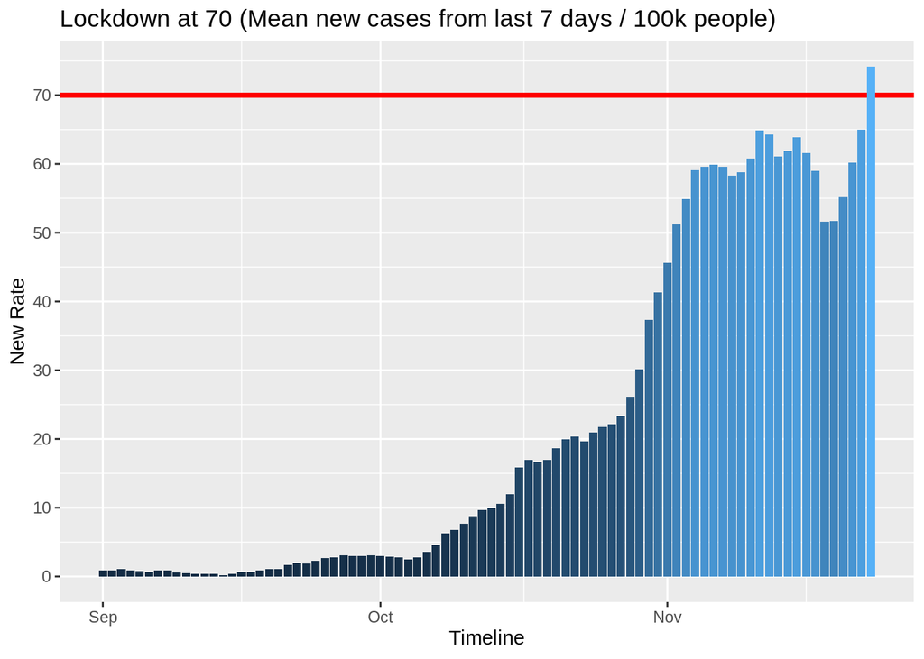

### More colorful times…

Previously, during more colorful times, when some places were called “green zone”, other were known as “yellow zone” and those with highest number of new infected people were called "red zones’. To be more precise, if in a given area the official old measure of disease was higher than 6 or 12, then the whole area (city or county - a few adjacent villages) changed color to yellow or red respectivly.

Those times are long gone, however the old measure can still be calculated with the following formula: Sum of new cases from previous 14 days divided by 10k people (quite different from the current measure, isn’t it?)

```
## [1] "Old measure today = 95"
```

Plot of old measure looks as follows:

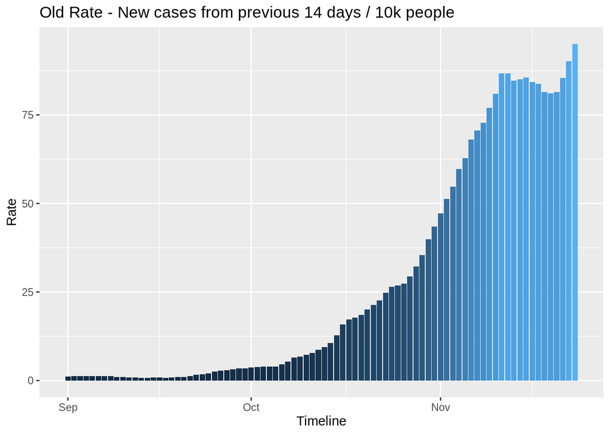

Changes of old measure from day to day are shown below:

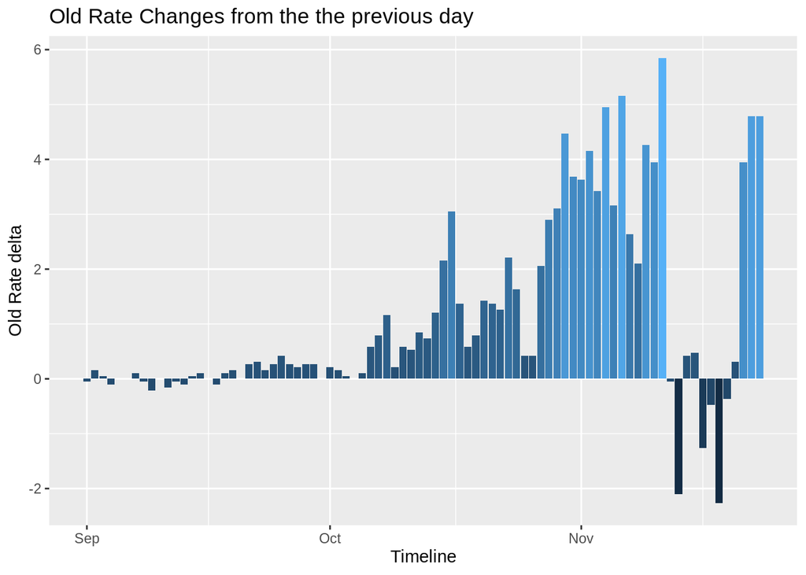

.

.

# Time for some more plots!

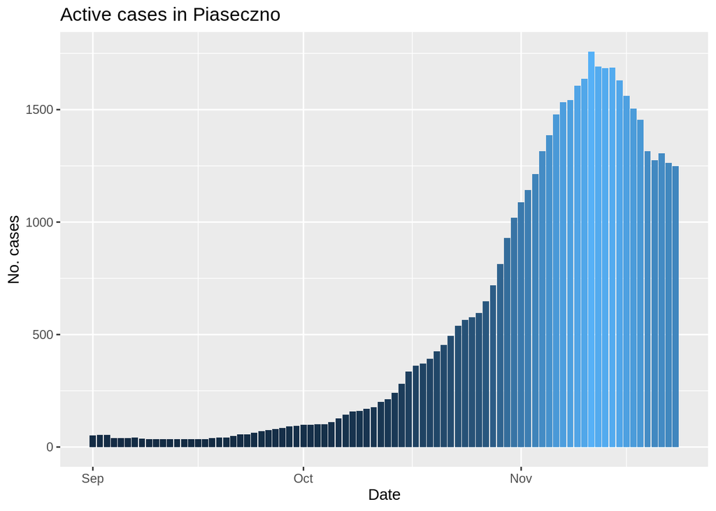

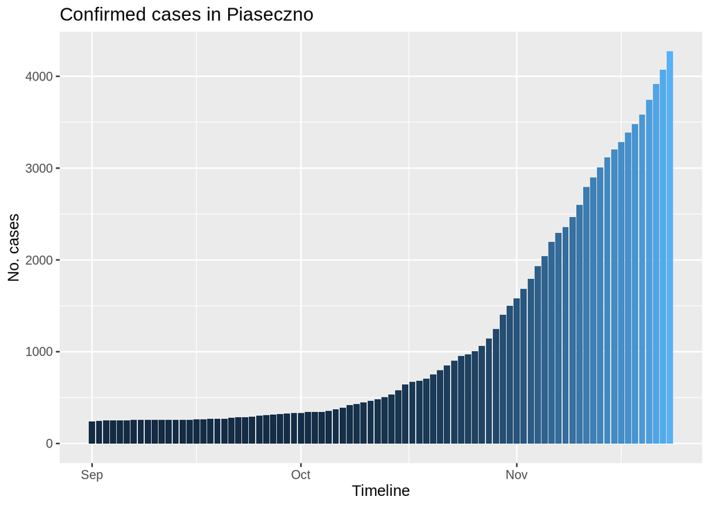

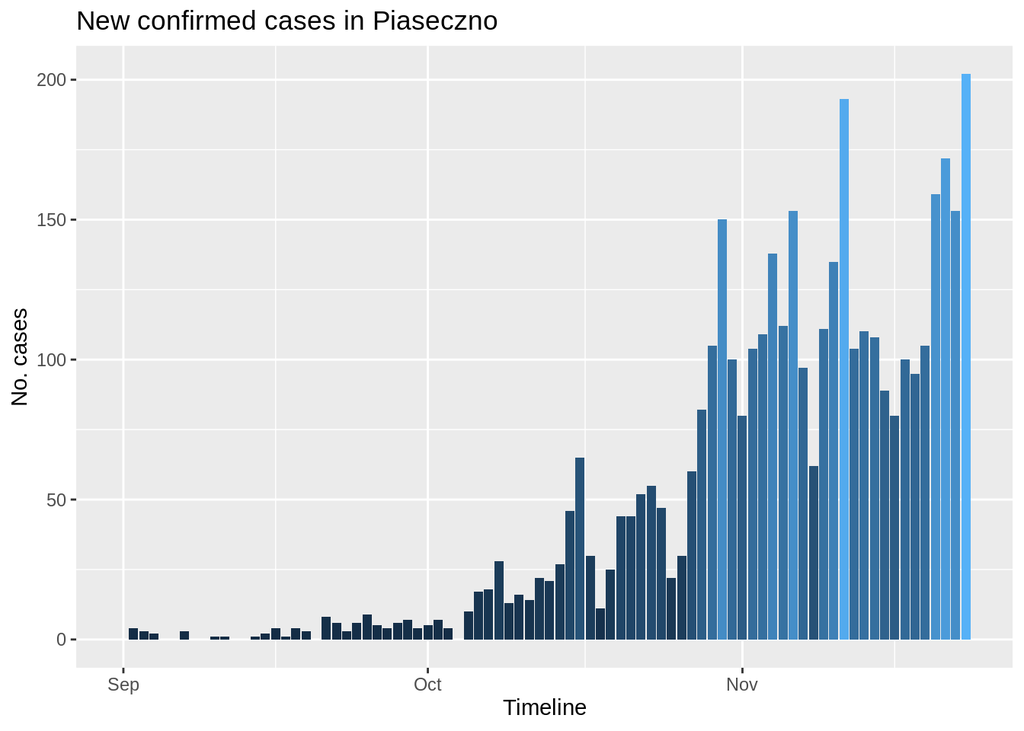

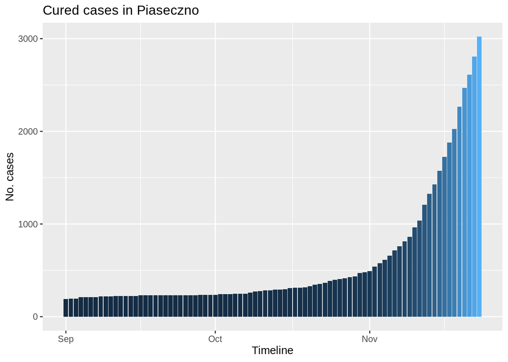

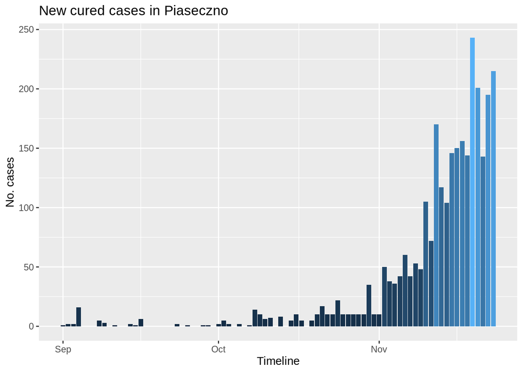

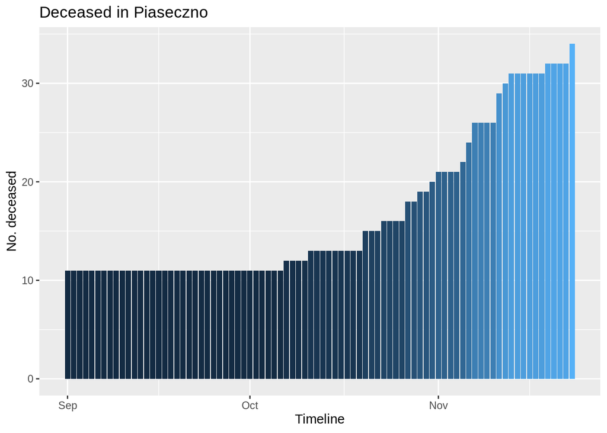

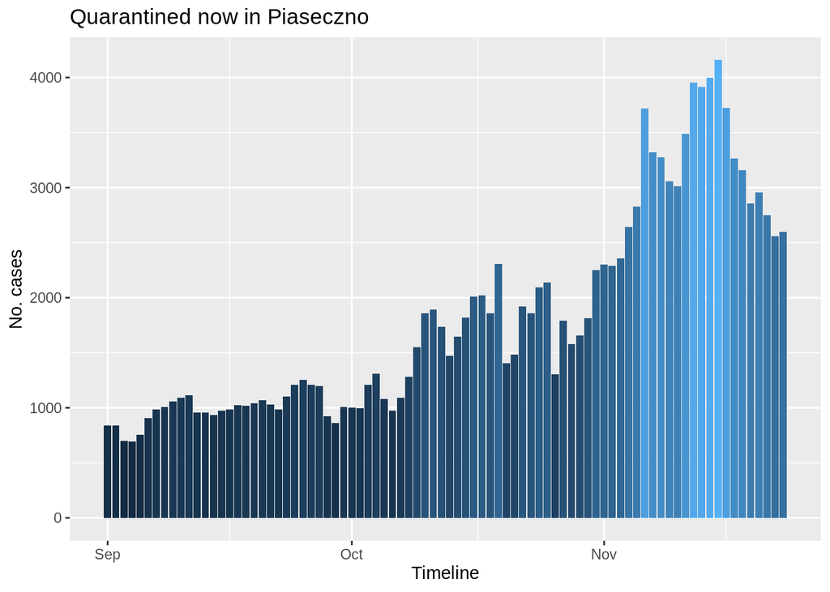

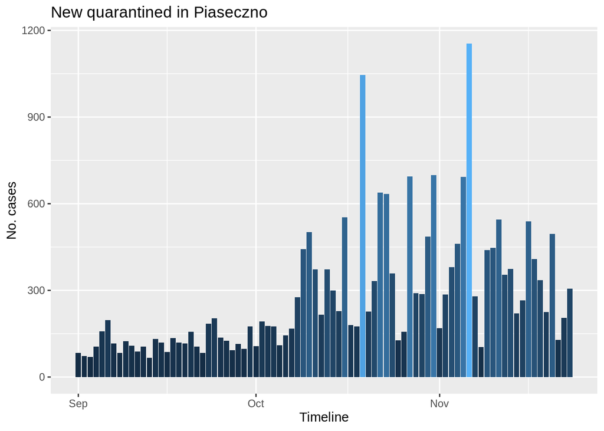